# Assessment 1

Sushmita Roy - 4651723

2022-03-04

```r
library(tidyverse)
library(knitr)

library(kableExtra)
```

```r
library(kableExtra)
library(ggplot2)
library(dplyr)
library(skimr)
```

# RMarkdown

*R Markdown provides an authoring framework for data science. You can use a single R Markdown file to save and execute code, and generate high quality reports that can be shared with an audience.R Markdown was designed for easier reproducibility, since both the computing code and narratives are in the same document, and results are automatically generated from the source code. R Markdown supports dozens of static and dynamic/interactive output formats.There are three basic components of an R Markdown document: the metadata, text, and code.*

https://rmarkdown.rstudio.com/lesson-8.html

```r
fastfood <-read.csv("https://raw.githubusercontent.com/rfordatascience/tidytuesday/master/data/2018/2018-09-04/fastfood_calories.csv")

  top_10 <- fastfood %>% head(10) %>%
  select(restaurant, item, calories, cal_fat, total_fat)

  top_10 %>% kable() %>% kable_styling() %>% scroll_box(width="90%", height="450px")
```

| restaurant | item | calories | cal_fat | total_fat |
| --- | --- | --- | --- | --- |
| Mcdonalds | Artisan Grilled Chicken Sandwich | 380 | 60 | 7 |
| Mcdonalds | Single Bacon Smokehouse Burger | 840 | 410 | 45 |
| Mcdonalds | Double Bacon Smokehouse Burger | 1130 | 600 | 67 |
| Mcdonalds | Grilled Bacon Smokehouse Chicken Sandwich | 750 | 280 | 31 |
| Mcdonalds | Crispy Bacon Smokehouse Chicken Sandwich | 920 | 410 | 45 |
| Mcdonalds | Big Mac | 540 | 250 | 28 |
| Mcdonalds | Cheeseburger | 300 | 100 | 12 |
| Mcdonalds | Classic Chicken Sandwich | 510 | 210 | 24 |
| Mcdonalds | Double Cheeseburger | 430 | 190 | 21 |
| Mcdonalds | Double Quarter PounderÂ® with Cheese | 770 | 400 | 45 |

### Part 2

### 8. Display the observations that has more than 1000 calories

```r
  fastfood_calories <- fastfood %>%  filter(calories > 1000)
    kable(fastfood_calories) %>% kable_styling() %>% scroll_box(width="100%", height="450px")
```

| X | restaurant | item | calories | cal_fat | total_fat | sat_fat | trans_fat | cholesterol | sodium | total_carb | fiber | sugar | protein | vit_a | vit_c | calcium | salad |
| --- | --- | --- | --- | --- | --- | --- | --- | --- | --- | --- | --- | --- | --- | --- | --- | --- | --- |
| 3 | Mcdonalds | Double Bacon Smokehouse Burger | 1130 | 600 | 67 | 27 | 3.0 | 220 | 1920 | 63 | 3 | 18 | 70 | 10 | 20 | 50 | Other |
| 38 | Mcdonalds | 10 piece Buttermilk Crispy Chicken Tenders | 1210 | 630 | 70 | 12 | 1.0 | 240 | 3230 | 52 | 1 | 4 | 94 | 0 | 0 | 4 | Other |
| 39 | Mcdonalds | 12 piece Buttermilk Crispy Chicken Tenders | 1510 | 790 | 88 | 15 | 1.0 | 295 | 3770 | 64 | 1 | 2 | 115 | 0 | 2 | 6 | Other |
| 40 | Mcdonalds | 20 piece Buttermilk Crispy Chicken Tenders | 2430 | 1270 | 141 | 24 | 2.0 | 475 | 6080 | 103 | 2 | 3 | 186 | 0 | 2 | 8 | Other |
| 45 | Mcdonalds | 40 piece Chicken McNuggets | 1770 | 960 | 107 | 18 | 0.5 | 295 | 3370 | 105 | 7 | 1 | 98 | 0 | 15 | 6 | Other |
| 48 | Mcdonalds | 10 piece Sweet N’ Spicy Honey BBQ Glazed Tenders | 1600 | 600 | 66 | 10 | 0.0 | 265 | 4450 | 156 | 5 | 87 | 97 | 8 | 40 | 10 | Other |
| 99 | Sonic | Super Sonic Bacon Double Cheeseburger (w/mayo) | 1280 | 830 | 92 | 36 | 4.0 | 260 | 1630 | 44 | 2 | 7 | 67 | 15 | 6 | 40 | Other |
| 100 | Sonic | Super Sonic Double Cheeseburger W/ Mustard | 1120 | 680 | 76 | 32 | 4.0 | 235 | 1550 | 44 | 2 | 8 | 63 | 15 | 8 | 40 | Other |
| 101 | Sonic | Super Sonic Double Cheeseburger W/ Ketchup | 1130 | 680 | 76 | 32 | 4.0 | 235 | 1620 | 47 | 2 | 11 | 63 | 20 | 10 | 40 | Other |
| 102 | Sonic | Super Sonic Double Cheeseburger W/ Mayo | 1220 | 780 | 87 | 34 | 4.0 | 245 | 1520 | 45 | 2 | 8 | 63 | 15 | 8 | 40 | Other |
| 103 | Sonic | Super Sonic Jalapeno Double Cheeseburger | 1120 | 680 | 76 | 32 | 4.0 | 235 | 1690 | 43 | 2 | 7 | 63 | 15 | 2 | 40 | Other |
| 116 | Sonic | Garlic Parmesan Dunked Ultimate Chicken Sandwich | 1350 | 900 | 100 | 17 | 0.0 | 190 | 2180 | 69 | 4 | 10 | 23 | NA | NA | NA | Other |
| 122 | Sonic | 4 Piece Super Crunch Chicken Strip Dinner | 1080 | 460 | 51 | 9 | 1.0 | 75 | 2390 | 118 | 8 | 9 | 37 | 1 | 7 | 13 | Other |
| 123 | Sonic | 5 Piece Super Crunch Chicken Strip Dinner | 1190 | 510 | 57 | 10 | 1.0 | 90 | 2610 | 126 | 8 | 9 | 44 | 2 | 8 | 14 | Other |
| 176 | Arbys | Triple Decker Sandwich | 1030 | 459 | 51 | 17 | 1.0 | 155 | 2940 | 83 | 5 | 19 | 62 | NA | NA | NA | Other |
| 193 | Burger King | American Brewhouse King | 1550 | 1134 | 126 | 47 | 8.0 | 805 | 1820 | 21 | 3 | 7 | 134 | NA | NA | NA | Other |
| 197 | Burger King | Bacon King | 1040 | 630 | 48 | 28 | 2.5 | 220 | 1900 | 48 | 1 | 10 | 57 | NA | NA | NA | Other |
| 199 | Burger King | BBQ Bacon King | 1100 | 675 | 75 | 29 | 3.0 | 220 | 1850 | 51 | NA | 13 | 57 | NA | NA | NA | Other |
| 206 | Burger King | Farmhouse King | 1220 | 720 | 80 | 28 | 3.0 | 335 | 2050 | 62 | NA | 15 | NA | NA | NA | NA | Other |
| 212 | Burger King | Rodeo King | 1250 | 738 | 82 | 31 | 3.5 | 230 | 2270 | 69 | 3 | 14 | 60 | NA | NA | NA | Other |
| 215 | Burger King | Steakhouse King | 1100 | 666 | 74 | 24 | 1.0 | 180 | 1620 | 59 | NA | 13 | 50 | NA | NA | NA | Other |
| 270 | Dairy Queen | 4 Piece Chicken Strip Basket w/ Country Gravy | 1030 | 480 | 53 | 9 | 1.0 | 80 | 2780 | 105 | 9 | 4 | 35 | 2 | 0 | 10 | Other |
| 271 | Dairy Queen | 6 Piece Chicken Strip Basket w/ Country Gravy | 1260 | 590 | 66 | 11 | 1.0 | 120 | 3500 | 121 | 12 | 4 | 49 | 2 | 0 | 10 | Other |
| 281 | Dairy Queen | Large Cheese Curds | 1050 | 670 | 75 | 43 | 1.0 | 180 | 2210 | 52 | 0 | 30 | 43 | NA | NA | NA | Other |
| 310 | Subway | Footlong Big Hot Pastrami | 1160 | 620 | 62 | 22 | 0.0 | 170 | 2940 | 94 | 10 | 14 | 58 | 20 | 90 | 80 | Other |
| 319 | Subway | Footlong Carved Turkey & Bacon w/ Cheese | 1140 | 460 | 52 | 14 | 0.0 | 140 | 3200 | 92 | 10 | 16 | 66 | 20 | 40 | 80 | Other |
| 321 | Subway | Footlong Chicken & Bacon Ranch Melt | 1140 | 500 | 56 | 20 | 2.0 | 190 | 2160 | 94 | 10 | 16 | 70 | 30 | 50 | 100 | Other |
| 331 | Subway | Footlong Italian Hero | 1100 | 520 | 58 | 20 | 0.0 | 150 | 2940 | 94 | 10 | 18 | 52 | 20 | 40 | 80 | Other |

```r
dont_eat_this <-fastfood %>% filter(total_fat > 40 & total_carb>80)
  kable(dont_eat_this) %>% kable_styling() %>% scroll_box(width="100%", height="450px")
```

| X | restaurant | item | calories | cal_fat | total_fat | sat_fat | trans_fat | cholesterol | sodium | total_carb | fiber | sugar | protein | vit_a | vit_c | calcium | salad |
| --- | --- | --- | --- | --- | --- | --- | --- | --- | --- | --- | --- | --- | --- | --- | --- | --- | --- |
| 5 | Mcdonalds | Crispy Bacon Smokehouse Chicken Sandwich | 920 | 410 | 45 | 12 | 0.5 | 120 | 1980 | 81 | 4 | 18 | 46 | 6 | 20 | 20 | Other |
| 40 | Mcdonalds | 20 piece Buttermilk Crispy Chicken Tenders | 2430 | 1270 | 141 | 24 | 2.0 | 475 | 6080 | 103 | 2 | 3 | 186 | 0 | 2 | 8 | Other |
| 45 | Mcdonalds | 40 piece Chicken McNuggets | 1770 | 960 | 107 | 18 | 0.5 | 295 | 3370 | 105 | 7 | 1 | 98 | 0 | 15 | 6 | Other |
| 48 | Mcdonalds | 10 piece Sweet N’ Spicy Honey BBQ Glazed Tenders | 1600 | 600 | 66 | 10 | 0.0 | 265 | 4450 | 156 | 5 | 87 | 97 | 8 | 40 | 10 | Other |
| 121 | Sonic | 3 Piece Super Crunch Chicken Strip Dinner | 970 | 410 | 46 | 8 | 1.0 | 55 | 2160 | 109 | 7 | 9 | 30 | 1 | 6 | 13 | Other |
| 122 | Sonic | 4 Piece Super Crunch Chicken Strip Dinner | 1080 | 460 | 51 | 9 | 1.0 | 75 | 2390 | 118 | 8 | 9 | 37 | 1 | 7 | 13 | Other |
| 123 | Sonic | 5 Piece Super Crunch Chicken Strip Dinner | 1190 | 510 | 57 | 10 | 1.0 | 90 | 2610 | 126 | 8 | 9 | 44 | 2 | 8 | 14 | Other |
| 161 | Arbys | Pecan Chicken Salad Sandwich | 840 | 400 | 44 | 6 | 0.5 | 75 | 1210 | 81 | 6 | 20 | 33 | 10 | 8 | 25 | Other |
| 176 | Arbys | Triple Decker Sandwich | 1030 | 459 | 51 | 17 | 1.0 | 155 | 2940 | 83 | 5 | 19 | 62 | NA | NA | NA | Other |
| 270 | Dairy Queen | 4 Piece Chicken Strip Basket w/ Country Gravy | 1030 | 480 | 53 | 9 | 1.0 | 80 | 2780 | 105 | 9 | 4 | 35 | 2 | 0 | 10 | Other |
| 271 | Dairy Queen | 6 Piece Chicken Strip Basket w/ Country Gravy | 1260 | 590 | 66 | 11 | 1.0 | 120 | 3500 | 121 | 12 | 4 | 49 | 2 | 0 | 10 | Other |
| 291 | Dairy Queen | Steak Finger Basket | 910 | 430 | 48 | 13 | 0.5 | 45 | 2210 | 95 | 5 | 2 | 23 | NA | NA | NA | Other |
| 310 | Subway | Footlong Big Hot Pastrami | 1160 | 620 | 62 | 22 | 0.0 | 170 | 2940 | 94 | 10 | 14 | 58 | 20 | 90 | 80 | Other |
| 319 | Subway | Footlong Carved Turkey & Bacon w/ Cheese | 1140 | 460 | 52 | 14 | 0.0 | 140 | 3200 | 92 | 10 | 16 | 66 | 20 | 40 | 80 | Other |
| 321 | Subway | Footlong Chicken & Bacon Ranch Melt | 1140 | 500 | 56 | 20 | 2.0 | 190 | 2160 | 94 | 10 | 16 | 70 | 30 | 50 | 100 | Other |
| 331 | Subway | Footlong Italian Hero | 1100 | 520 | 58 | 20 | 0.0 | 150 | 2940 | 94 | 10 | 18 | 52 | 20 | 40 | 80 | Other |
| 342 | Subway | Footlong Spicy Italian | 960 | 440 | 48 | 18 | 2.0 | 100 | 3040 | 92 | 10 | 16 | 40 | 16 | 40 | 60 | Other |
| 354 | Subway | Footlong Tuna | 940 | 420 | 48 | 8 | 0.0 | 60 | 1240 | 88 | 10 | 12 | 40 | 16 | 40 | 60 | Other |
| 363 | Subway | Footlong Turkey Italiano Melt (with Provolone) | 980 | 420 | 48 | 18 | 2.0 | 100 | 2960 | 94 | 10 | 16 | 48 | 20 | 40 | 90 | Other |
| 431 | Taco Bell | XXL Grilled Stuft Burrito - Beef | 880 | 380 | 42 | 14 | 1.0 | 75 | 2020 | 94 | 12 | 6 | 31 | NA | NA | NA | Other |

### 10. Using the initial dataset variable, use `case_when()` to create a new variable `heavy_food` which is equal to “heavy” when total calories are greater than 500, “low” when total calories are less than 250 and “average” for all other cases. Count the number of observations in each created category.

```r
heavy_food_data <- fastfood %>%
  mutate(heavy_food=case_when(calories>500 ~ 'heavy',
                             calories<250 ~ 'low',
                             TRUE ~ 'Average')) %>%
                  count(heavy_food)


    kable(heavy_food_data) %>% kable_styling() %>% scroll_box(width="100%", height="150px")
```

| heavy_food | n |
| --- | --- |
| Average | 201 |
| heavy | 246 |
| low | 68 |

### 11. Display the types of variables in the dataset using `skimr` package

```r
skim(fastfood)
```

Data summary

| Name | fastfood |
| --- | --- |
| Number of rows | 515 |
| Number of columns | 18 |
| _______________________ |  |
| Column type frequency: |  |
| character | 3 |
| numeric | 15 |
| ________________________ |  |
| Group variables | None |

**Variable type: character**

| skim_variable | n_missing | complete_rate | min | max | empty | n_unique | whitespace |
| --- | --- | --- | --- | --- | --- | --- | --- |
| restaurant | 0 | 1 | 5 | 11 | 0 | 8 | 0 |
| item | 0 | 1 | 5 | 63 | 0 | 505 | 0 |
| salad | 0 | 1 | 5 | 5 | 0 | 1 | 0 |

**Variable type: numeric**

| skim_variable | n_missing | complete_rate | mean | sd | p0 | p25 | p50 | p75 | p100 | hist |
| --- | --- | --- | --- | --- | --- | --- | --- | --- | --- | --- |
| X | 0 | 1.00 | 258.00 | 148.81 | 1 | 129.5 | 258.0 | 386.5 | 515 | ▇▇▇▇▇ |
| calories | 0 | 1.00 | 530.91 | 282.44 | 20 | 330.0 | 490.0 | 690.0 | 2430 | ▇▆▁▁▁ |
| cal_fat | 0 | 1.00 | 238.81 | 166.41 | 0 | 120.0 | 210.0 | 310.0 | 1270 | ▇▃▁▁▁ |
| total_fat | 0 | 1.00 | 26.59 | 18.41 | 0 | 14.0 | 23.0 | 35.0 | 141 | ▇▃▁▁▁ |
| sat_fat | 0 | 1.00 | 8.15 | 6.42 | 0 | 4.0 | 7.0 | 11.0 | 47 | ▇▃▁▁▁ |
| trans_fat | 0 | 1.00 | 0.47 | 0.84 | 0 | 0.0 | 0.0 | 1.0 | 8 | ▇▁▁▁▁ |
| cholesterol | 0 | 1.00 | 72.46 | 63.16 | 0 | 35.0 | 60.0 | 95.0 | 805 | ▇▁▁▁▁ |
| sodium | 0 | 1.00 | 1246.74 | 689.95 | 15 | 800.0 | 1110.0 | 1550.0 | 6080 | ▇▆▁▁▁ |
| total_carb | 0 | 1.00 | 45.66 | 24.88 | 0 | 28.5 | 44.0 | 57.0 | 156 | ▅▇▂▁▁ |
| fiber | 12 | 0.98 | 4.14 | 3.04 | 0 | 2.0 | 3.0 | 5.0 | 17 | ▇▅▂▁▁ |
| sugar | 0 | 1.00 | 7.26 | 6.76 | 0 | 3.0 | 6.0 | 9.0 | 87 | ▇▁▁▁▁ |
| protein | 1 | 1.00 | 27.89 | 17.68 | 1 | 16.0 | 24.5 | 36.0 | 186 | ▇▂▁▁▁ |
| vit_a | 214 | 0.58 | 18.86 | 31.38 | 0 | 4.0 | 10.0 | 20.0 | 180 | ▇▁▁▁▁ |
| vit_c | 210 | 0.59 | 20.17 | 30.59 | 0 | 4.0 | 10.0 | 30.0 | 400 | ▇▁▁▁▁ |
| calcium | 210 | 0.59 | 24.85 | 25.52 | 0 | 8.0 | 20.0 | 30.0 | 290 | ▇▁▁▁▁ |

```r
fastfood %>%
  count(restaurant) %>%
  arrange(desc(n))
```

```
##    restaurant   n
## 1   Taco Bell 115
## 2      Subway  96
## 3 Burger King  70
## 4   Mcdonalds  57
## 5       Arbys  55
## 6       Sonic  53
## 7 Dairy Queen  42
## 8 Chick Fil-A  27
```

```r
fastfood %>%
  group_by(restaurant) %>%
  mutate(avg_calories = mean(calories)) %>%
  ungroup() %>%
  kable() %>% kable_styling() %>% scroll_box(width="100%", height="450px")
```

| X | restaurant | item | calories | cal_fat | total_fat | sat_fat | trans_fat | cholesterol | sodium | total_carb | fiber | sugar | protein | vit_a | vit_c | calcium | salad | avg_calories |
| --- | --- | --- | --- | --- | --- | --- | --- | --- | --- | --- | --- | --- | --- | --- | --- | --- | --- | --- |
| 1 | Mcdonalds | Artisan Grilled Chicken Sandwich | 380 | 60 | 7 | 2.0 | 0.0 | 95 | 1110 | 44 | 3 | 11 | 37 | 4 | 20 | 20 | Other | 640.3509 |
| 2 | Mcdonalds | Single Bacon Smokehouse Burger | 840 | 410 | 45 | 17.0 | 1.5 | 130 | 1580 | 62 | 2 | 18 | 46 | 6 | 20 | 20 | Other | 640.3509 |
| 3 | Mcdonalds | Double Bacon Smokehouse Burger | 1130 | 600 | 67 | 27.0 | 3.0 | 220 | 1920 | 63 | 3 | 18 | 70 | 10 | 20 | 50 | Other | 640.3509 |
| 4 | Mcdonalds | Grilled Bacon Smokehouse Chicken Sandwich | 750 | 280 | 31 | 10.0 | 0.5 | 155 | 1940 | 62 | 2 | 18 | 55 | 6 | 25 | 20 | Other | 640.3509 |
| 5 | Mcdonalds | Crispy Bacon Smokehouse Chicken Sandwich | 920 | 410 | 45 | 12.0 | 0.5 | 120 | 1980 | 81 | 4 | 18 | 46 | 6 | 20 | 20 | Other | 640.3509 |
| 6 | Mcdonalds | Big Mac | 540 | 250 | 28 | 10.0 | 1.0 | 80 | 950 | 46 | 3 | 9 | 25 | 10 | 2 | 15 | Other | 640.3509 |
| 7 | Mcdonalds | Cheeseburger | 300 | 100 | 12 | 5.0 | 0.5 | 40 | 680 | 33 | 2 | 7 | 15 | 10 | 2 | 10 | Other | 640.3509 |
| 8 | Mcdonalds | Classic Chicken Sandwich | 510 | 210 | 24 | 4.0 | 0.0 | 65 | 1040 | 49 | 3 | 6 | 25 | 0 | 4 | 2 | Other | 640.3509 |
| 9 | Mcdonalds | Double Cheeseburger | 430 | 190 | 21 | 11.0 | 1.0 | 85 | 1040 | 35 | 2 | 7 | 25 | 20 | 4 | 15 | Other | 640.3509 |
| 10 | Mcdonalds | Double Quarter Pounder® with Cheese | 770 | 400 | 45 | 21.0 | 2.5 | 175 | 1290 | 42 | 3 | 10 | 51 | 20 | 6 | 20 | Other | 640.3509 |
| 11 | Mcdonalds | Filet-O-Fish® | 380 | 170 | 18 | 4.0 | 0.0 | 40 | 640 | 38 | 2 | 5 | 15 | 2 | 0 | 15 | Other | 640.3509 |
| 12 | Mcdonalds | Garlic White Cheddar Burger | 620 | 300 | 34 | 13.0 | 1.5 | 95 | 790 | 48 | 3 | 11 | 32 | 10 | 10 | 35 | Other | 640.3509 |
| 13 | Mcdonalds | Grilled Garlic White Cheddar Chicken Sandwich | 530 | 180 | 20 | 7.0 | 0.0 | 125 | 1150 | 48 | 3 | 11 | 42 | 10 | 20 | 35 | Other | 640.3509 |
| 14 | Mcdonalds | Crispy Garlic White Cheddar Chicken Sandwich | 700 | 300 | 34 | 9.0 | 0.0 | 85 | 1190 | 67 | 5 | 11 | 33 | 10 | 15 | 35 | Other | 640.3509 |
| 15 | Mcdonalds | Hamburger | 250 | 70 | 8 | 3.0 | 0.0 | 30 | 480 | 31 | 2 | 6 | 13 | 2 | 2 | 4 | Other | 640.3509 |
| 16 | Mcdonalds | Lobster Roll | 290 | 50 | 5 | 1.5 | 0.0 | 65 | 630 | 35 | 2 | 3 | 24 | 4 | 6 | 15 | Other | 640.3509 |
| 17 | Mcdonalds | Maple Bacon Dijon 1/4 lb Burger | 640 | 330 | 36 | 14.0 | 1.5 | 110 | 1260 | 40 | 3 | 10 | 37 | 6 | 15 | 15 | Other | 640.3509 |
| 18 | Mcdonalds | Grilled Maple Bacon Dijon Chicken Sandwich | 580 | 190 | 21 | 8.0 | 0.0 | 135 | 1890 | 50 | 3 | 14 | 48 | 4 | 30 | 30 | Other | 640.3509 |
| 19 | Mcdonalds | Crispy Maple Bacon Dijon Chicken Sandwich | 740 | 310 | 35 | 9.0 | 0.5 | 95 | 1780 | 69 | 5 | 14 | 39 | 4 | 20 | 290 | Other | 640.3509 |
| 20 | Mcdonalds | McChicken | 350 | 130 | 15 | 3.5 | 0.0 | 40 | 600 | 40 | 2 | 5 | 15 | 2 | 2 | 4 | Other | 640.3509 |
| 21 | Mcdonalds | McDouble | 380 | 160 | 18 | 8.0 | 1.0 | 70 | 840 | 34 | 2 | 7 | 23 | 10 | 2 | 10 | Other | 640.3509 |
| 22 | Mcdonalds | McRib | 480 | 200 | 22 | 7.0 | 0.0 | 80 | 870 | 45 | 2 | 12 | 25 | 2 | 2 | 6 | Other | 640.3509 |
| 23 | Mcdonalds | Pico Guacamole 1/4 lb Burger | 580 | 300 | 33 | 12.0 | 1.5 | 95 | 920 | 41 | 4 | 7 | 29 | 8 | 15 | 15 | Other | 640.3509 |
| 24 | Mcdonalds | Grilled Pico Guacamole Chicken Sandwich | 520 | 160 | 18 | 6.0 | 0.0 | 115 | 1540 | 50 | 4 | 12 | 40 | 8 | 25 | 30 | Other | 640.3509 |
| 25 | Mcdonalds | Crispy Pico Guacamole Chicken Sandwich | 680 | 280 | 32 | 7.0 | 0.0 | 80 | 1430 | 69 | 6 | 12 | 31 | 8 | 15 | 30 | Other | 640.3509 |
| 26 | Mcdonalds | Premium Buttermilk Crispy Chicken Deluxe Sandwich | 570 | 200 | 23 | 5.0 | 0.0 | 60 | 1050 | 64 | 4 | 11 | 28 | 4 | 10 | 20 | Other | 640.3509 |
| 27 | Mcdonalds | Premium Crispy Chicken Deluxe Sandwich | 530 | 200 | 22 | 4.0 | 0.0 | 45 | 1000 | 59 | 3 | 13 | 25 | 6 | 10 | 20 | Other | 640.3509 |
| 28 | Mcdonalds | Quarter Pounder® with Cheese | 530 | 240 | 27 | 13.0 | 1.5 | 100 | 1090 | 41 | 3 | 10 | 31 | 20 | 6 | 15 | Other | 640.3509 |
| 29 | Mcdonalds | Signature Sriracha Burger | 670 | 320 | 35 | 12.0 | 1.5 | 95 | 1010 | 56 | 4 | 13 | 32 | 20 | 15 | 30 | Other | 640.3509 |
| 30 | Mcdonalds | Grilled Signature Sriracha Chicken Sandwich | 560 | 180 | 20 | 5.0 | 0.0 | 115 | 1550 | 56 | 4 | 14 | 41 | 20 | 25 | 30 | Other | 640.3509 |

[output cut: 485 more lines]

```r
summary(fastfood)
```

```
##        X          restaurant            item              calories
##  Min.   :  1.0   Length:515         Length:515         Min.   :  20.0
##  1st Qu.:129.5   Class :character   Class :character   1st Qu.: 330.0
##  Median :258.0   Mode  :character   Mode  :character   Median : 490.0
##  Mean   :258.0                                         Mean   : 530.9
##  3rd Qu.:386.5                                         3rd Qu.: 690.0
##  Max.   :515.0                                         Max.   :2430.0
##
##     cal_fat         total_fat         sat_fat         trans_fat
##  Min.   :   0.0   Min.   :  0.00   Min.   : 0.000   Min.   :0.000
##  1st Qu.: 120.0   1st Qu.: 14.00   1st Qu.: 4.000   1st Qu.:0.000
##  Median : 210.0   Median : 23.00   Median : 7.000   Median :0.000
##  Mean   : 238.8   Mean   : 26.59   Mean   : 8.153   Mean   :0.465
##  3rd Qu.: 310.0   3rd Qu.: 35.00   3rd Qu.:11.000   3rd Qu.:1.000
##  Max.   :1270.0   Max.   :141.00   Max.   :47.000   Max.   :8.000
##
##   cholesterol         sodium       total_carb         fiber
##  Min.   :  0.00   Min.   :  15   Min.   :  0.00   Min.   : 0.000
##  1st Qu.: 35.00   1st Qu.: 800   1st Qu.: 28.50   1st Qu.: 2.000
##  Median : 60.00   Median :1110   Median : 44.00   Median : 3.000
##  Mean   : 72.46   Mean   :1247   Mean   : 45.66   Mean   : 4.137
##  3rd Qu.: 95.00   3rd Qu.:1550   3rd Qu.: 57.00   3rd Qu.: 5.000
##  Max.   :805.00   Max.   :6080   Max.   :156.00   Max.   :17.000
##                                                   NA's   :12
##      sugar           protein           vit_a            vit_c
##  Min.   : 0.000   Min.   :  1.00   Min.   :  0.00   Min.   :  0.00
##  1st Qu.: 3.000   1st Qu.: 16.00   1st Qu.:  4.00   1st Qu.:  4.00
##  Median : 6.000   Median : 24.50   Median : 10.00   Median : 10.00
##  Mean   : 7.262   Mean   : 27.89   Mean   : 18.86   Mean   : 20.17
##  3rd Qu.: 9.000   3rd Qu.: 36.00   3rd Qu.: 20.00   3rd Qu.: 30.00
##  Max.   :87.000   Max.   :186.00   Max.   :180.00   Max.   :400.00
##                   NA's   :1        NA's   :214      NA's   :210
##     calcium          salad
##  Min.   :  0.00   Length:515
##  1st Qu.:  8.00   Class :character
##  Median : 20.00   Mode  :character
##  Mean   : 24.85
##  3rd Qu.: 30.00
##  Max.   :290.00
##  NA's   :210
```

### 14. Add variables to the dataset, which:

```r
fastfood %>%
  mutate(average_calories = mean(calories),
         max_fat = max(total_fat),
         min_cholesterol = min(cholesterol)) %>%
    kable() %>% kable_styling() %>% scroll_box(width="100%", height="450px")
```

| X | restaurant | item | calories | cal_fat | total_fat | sat_fat | trans_fat | cholesterol | sodium | total_carb | fiber | sugar | protein | vit_a | vit_c | calcium | salad | average_calories | max_fat | min_cholesterol |
| --- | --- | --- | --- | --- | --- | --- | --- | --- | --- | --- | --- | --- | --- | --- | --- | --- | --- | --- | --- | --- |
| 1 | Mcdonalds | Artisan Grilled Chicken Sandwich | 380 | 60 | 7 | 2.0 | 0.0 | 95 | 1110 | 44 | 3 | 11 | 37 | 4 | 20 | 20 | Other | 530.9126 | 141 | 0 |
| 2 | Mcdonalds | Single Bacon Smokehouse Burger | 840 | 410 | 45 | 17.0 | 1.5 | 130 | 1580 | 62 | 2 | 18 | 46 | 6 | 20 | 20 | Other | 530.9126 | 141 | 0 |
| 3 | Mcdonalds | Double Bacon Smokehouse Burger | 1130 | 600 | 67 | 27.0 | 3.0 | 220 | 1920 | 63 | 3 | 18 | 70 | 10 | 20 | 50 | Other | 530.9126 | 141 | 0 |
| 4 | Mcdonalds | Grilled Bacon Smokehouse Chicken Sandwich | 750 | 280 | 31 | 10.0 | 0.5 | 155 | 1940 | 62 | 2 | 18 | 55 | 6 | 25 | 20 | Other | 530.9126 | 141 | 0 |
| 5 | Mcdonalds | Crispy Bacon Smokehouse Chicken Sandwich | 920 | 410 | 45 | 12.0 | 0.5 | 120 | 1980 | 81 | 4 | 18 | 46 | 6 | 20 | 20 | Other | 530.9126 | 141 | 0 |
| 6 | Mcdonalds | Big Mac | 540 | 250 | 28 | 10.0 | 1.0 | 80 | 950 | 46 | 3 | 9 | 25 | 10 | 2 | 15 | Other | 530.9126 | 141 | 0 |
| 7 | Mcdonalds | Cheeseburger | 300 | 100 | 12 | 5.0 | 0.5 | 40 | 680 | 33 | 2 | 7 | 15 | 10 | 2 | 10 | Other | 530.9126 | 141 | 0 |
| 8 | Mcdonalds | Classic Chicken Sandwich | 510 | 210 | 24 | 4.0 | 0.0 | 65 | 1040 | 49 | 3 | 6 | 25 | 0 | 4 | 2 | Other | 530.9126 | 141 | 0 |
| 9 | Mcdonalds | Double Cheeseburger | 430 | 190 | 21 | 11.0 | 1.0 | 85 | 1040 | 35 | 2 | 7 | 25 | 20 | 4 | 15 | Other | 530.9126 | 141 | 0 |
| 10 | Mcdonalds | Double Quarter Pounder® with Cheese | 770 | 400 | 45 | 21.0 | 2.5 | 175 | 1290 | 42 | 3 | 10 | 51 | 20 | 6 | 20 | Other | 530.9126 | 141 | 0 |
| 11 | Mcdonalds | Filet-O-Fish® | 380 | 170 | 18 | 4.0 | 0.0 | 40 | 640 | 38 | 2 | 5 | 15 | 2 | 0 | 15 | Other | 530.9126 | 141 | 0 |
| 12 | Mcdonalds | Garlic White Cheddar Burger | 620 | 300 | 34 | 13.0 | 1.5 | 95 | 790 | 48 | 3 | 11 | 32 | 10 | 10 | 35 | Other | 530.9126 | 141 | 0 |
| 13 | Mcdonalds | Grilled Garlic White Cheddar Chicken Sandwich | 530 | 180 | 20 | 7.0 | 0.0 | 125 | 1150 | 48 | 3 | 11 | 42 | 10 | 20 | 35 | Other | 530.9126 | 141 | 0 |
| 14 | Mcdonalds | Crispy Garlic White Cheddar Chicken Sandwich | 700 | 300 | 34 | 9.0 | 0.0 | 85 | 1190 | 67 | 5 | 11 | 33 | 10 | 15 | 35 | Other | 530.9126 | 141 | 0 |
| 15 | Mcdonalds | Hamburger | 250 | 70 | 8 | 3.0 | 0.0 | 30 | 480 | 31 | 2 | 6 | 13 | 2 | 2 | 4 | Other | 530.9126 | 141 | 0 |
| 16 | Mcdonalds | Lobster Roll | 290 | 50 | 5 | 1.5 | 0.0 | 65 | 630 | 35 | 2 | 3 | 24 | 4 | 6 | 15 | Other | 530.9126 | 141 | 0 |
| 17 | Mcdonalds | Maple Bacon Dijon 1/4 lb Burger | 640 | 330 | 36 | 14.0 | 1.5 | 110 | 1260 | 40 | 3 | 10 | 37 | 6 | 15 | 15 | Other | 530.9126 | 141 | 0 |
| 18 | Mcdonalds | Grilled Maple Bacon Dijon Chicken Sandwich | 580 | 190 | 21 | 8.0 | 0.0 | 135 | 1890 | 50 | 3 | 14 | 48 | 4 | 30 | 30 | Other | 530.9126 | 141 | 0 |
| 19 | Mcdonalds | Crispy Maple Bacon Dijon Chicken Sandwich | 740 | 310 | 35 | 9.0 | 0.5 | 95 | 1780 | 69 | 5 | 14 | 39 | 4 | 20 | 290 | Other | 530.9126 | 141 | 0 |
| 20 | Mcdonalds | McChicken | 350 | 130 | 15 | 3.5 | 0.0 | 40 | 600 | 40 | 2 | 5 | 15 | 2 | 2 | 4 | Other | 530.9126 | 141 | 0 |
| 21 | Mcdonalds | McDouble | 380 | 160 | 18 | 8.0 | 1.0 | 70 | 840 | 34 | 2 | 7 | 23 | 10 | 2 | 10 | Other | 530.9126 | 141 | 0 |
| 22 | Mcdonalds | McRib | 480 | 200 | 22 | 7.0 | 0.0 | 80 | 870 | 45 | 2 | 12 | 25 | 2 | 2 | 6 | Other | 530.9126 | 141 | 0 |
| 23 | Mcdonalds | Pico Guacamole 1/4 lb Burger | 580 | 300 | 33 | 12.0 | 1.5 | 95 | 920 | 41 | 4 | 7 | 29 | 8 | 15 | 15 | Other | 530.9126 | 141 | 0 |
| 24 | Mcdonalds | Grilled Pico Guacamole Chicken Sandwich | 520 | 160 | 18 | 6.0 | 0.0 | 115 | 1540 | 50 | 4 | 12 | 40 | 8 | 25 | 30 | Other | 530.9126 | 141 | 0 |
| 25 | Mcdonalds | Crispy Pico Guacamole Chicken Sandwich | 680 | 280 | 32 | 7.0 | 0.0 | 80 | 1430 | 69 | 6 | 12 | 31 | 8 | 15 | 30 | Other | 530.9126 | 141 | 0 |
| 26 | Mcdonalds | Premium Buttermilk Crispy Chicken Deluxe Sandwich | 570 | 200 | 23 | 5.0 | 0.0 | 60 | 1050 | 64 | 4 | 11 | 28 | 4 | 10 | 20 | Other | 530.9126 | 141 | 0 |
| 27 | Mcdonalds | Premium Crispy Chicken Deluxe Sandwich | 530 | 200 | 22 | 4.0 | 0.0 | 45 | 1000 | 59 | 3 | 13 | 25 | 6 | 10 | 20 | Other | 530.9126 | 141 | 0 |
| 28 | Mcdonalds | Quarter Pounder® with Cheese | 530 | 240 | 27 | 13.0 | 1.5 | 100 | 1090 | 41 | 3 | 10 | 31 | 20 | 6 | 15 | Other | 530.9126 | 141 | 0 |
| 29 | Mcdonalds | Signature Sriracha Burger | 670 | 320 | 35 | 12.0 | 1.5 | 95 | 1010 | 56 | 4 | 13 | 32 | 20 | 15 | 30 | Other | 530.9126 | 141 | 0 |
| 30 | Mcdonalds | Grilled Signature Sriracha Chicken Sandwich | 560 | 180 | 20 | 5.0 | 0.0 | 115 | 1550 | 56 | 4 | 14 | 41 | 20 | 25 | 30 | Other | 530.9126 | 141 | 0 |

[output cut: 485 more lines]

```r
fastfood%>% select(restaurant, total_fat) %>%
            group_by(restaurant) %>%
              ungroup()
```

```
## # A tibble: 515 x 2
##    restaurant total_fat
##    <chr>          <int>
##  1 Mcdonalds          7
##  2 Mcdonalds         45
##  3 Mcdonalds         67
##  4 Mcdonalds         31
##  5 Mcdonalds         45
##  6 Mcdonalds         28
##  7 Mcdonalds         12
##  8 Mcdonalds         24
##  9 Mcdonalds         21
## 10 Mcdonalds         45
## # ... with 505 more rows
```

```r
fastfood %>%
  mutate(cholesterol_sodium = sum(cholesterol,sodium)) %>%
   kable() %>% kable_styling() %>% scroll_box(width="100%", height="450px")
```

| X | restaurant | item | calories | cal_fat | total_fat | sat_fat | trans_fat | cholesterol | sodium | total_carb | fiber | sugar | protein | vit_a | vit_c | calcium | salad | cholesterol_sodium |
| --- | --- | --- | --- | --- | --- | --- | --- | --- | --- | --- | --- | --- | --- | --- | --- | --- | --- | --- |
| 1 | Mcdonalds | Artisan Grilled Chicken Sandwich | 380 | 60 | 7 | 2.0 | 0.0 | 95 | 1110 | 44 | 3 | 11 | 37 | 4 | 20 | 20 | Other | 679385 |
| 2 | Mcdonalds | Single Bacon Smokehouse Burger | 840 | 410 | 45 | 17.0 | 1.5 | 130 | 1580 | 62 | 2 | 18 | 46 | 6 | 20 | 20 | Other | 679385 |
| 3 | Mcdonalds | Double Bacon Smokehouse Burger | 1130 | 600 | 67 | 27.0 | 3.0 | 220 | 1920 | 63 | 3 | 18 | 70 | 10 | 20 | 50 | Other | 679385 |
| 4 | Mcdonalds | Grilled Bacon Smokehouse Chicken Sandwich | 750 | 280 | 31 | 10.0 | 0.5 | 155 | 1940 | 62 | 2 | 18 | 55 | 6 | 25 | 20 | Other | 679385 |
| 5 | Mcdonalds | Crispy Bacon Smokehouse Chicken Sandwich | 920 | 410 | 45 | 12.0 | 0.5 | 120 | 1980 | 81 | 4 | 18 | 46 | 6 | 20 | 20 | Other | 679385 |
| 6 | Mcdonalds | Big Mac | 540 | 250 | 28 | 10.0 | 1.0 | 80 | 950 | 46 | 3 | 9 | 25 | 10 | 2 | 15 | Other | 679385 |
| 7 | Mcdonalds | Cheeseburger | 300 | 100 | 12 | 5.0 | 0.5 | 40 | 680 | 33 | 2 | 7 | 15 | 10 | 2 | 10 | Other | 679385 |
| 8 | Mcdonalds | Classic Chicken Sandwich | 510 | 210 | 24 | 4.0 | 0.0 | 65 | 1040 | 49 | 3 | 6 | 25 | 0 | 4 | 2 | Other | 679385 |
| 9 | Mcdonalds | Double Cheeseburger | 430 | 190 | 21 | 11.0 | 1.0 | 85 | 1040 | 35 | 2 | 7 | 25 | 20 | 4 | 15 | Other | 679385 |
| 10 | Mcdonalds | Double Quarter Pounder® with Cheese | 770 | 400 | 45 | 21.0 | 2.5 | 175 | 1290 | 42 | 3 | 10 | 51 | 20 | 6 | 20 | Other | 679385 |
| 11 | Mcdonalds | Filet-O-Fish® | 380 | 170 | 18 | 4.0 | 0.0 | 40 | 640 | 38 | 2 | 5 | 15 | 2 | 0 | 15 | Other | 679385 |
| 12 | Mcdonalds | Garlic White Cheddar Burger | 620 | 300 | 34 | 13.0 | 1.5 | 95 | 790 | 48 | 3 | 11 | 32 | 10 | 10 | 35 | Other | 679385 |
| 13 | Mcdonalds | Grilled Garlic White Cheddar Chicken Sandwich | 530 | 180 | 20 | 7.0 | 0.0 | 125 | 1150 | 48 | 3 | 11 | 42 | 10 | 20 | 35 | Other | 679385 |
| 14 | Mcdonalds | Crispy Garlic White Cheddar Chicken Sandwich | 700 | 300 | 34 | 9.0 | 0.0 | 85 | 1190 | 67 | 5 | 11 | 33 | 10 | 15 | 35 | Other | 679385 |
| 15 | Mcdonalds | Hamburger | 250 | 70 | 8 | 3.0 | 0.0 | 30 | 480 | 31 | 2 | 6 | 13 | 2 | 2 | 4 | Other | 679385 |
| 16 | Mcdonalds | Lobster Roll | 290 | 50 | 5 | 1.5 | 0.0 | 65 | 630 | 35 | 2 | 3 | 24 | 4 | 6 | 15 | Other | 679385 |
| 17 | Mcdonalds | Maple Bacon Dijon 1/4 lb Burger | 640 | 330 | 36 | 14.0 | 1.5 | 110 | 1260 | 40 | 3 | 10 | 37 | 6 | 15 | 15 | Other | 679385 |
| 18 | Mcdonalds | Grilled Maple Bacon Dijon Chicken Sandwich | 580 | 190 | 21 | 8.0 | 0.0 | 135 | 1890 | 50 | 3 | 14 | 48 | 4 | 30 | 30 | Other | 679385 |
| 19 | Mcdonalds | Crispy Maple Bacon Dijon Chicken Sandwich | 740 | 310 | 35 | 9.0 | 0.5 | 95 | 1780 | 69 | 5 | 14 | 39 | 4 | 20 | 290 | Other | 679385 |
| 20 | Mcdonalds | McChicken | 350 | 130 | 15 | 3.5 | 0.0 | 40 | 600 | 40 | 2 | 5 | 15 | 2 | 2 | 4 | Other | 679385 |
| 21 | Mcdonalds | McDouble | 380 | 160 | 18 | 8.0 | 1.0 | 70 | 840 | 34 | 2 | 7 | 23 | 10 | 2 | 10 | Other | 679385 |
| 22 | Mcdonalds | McRib | 480 | 200 | 22 | 7.0 | 0.0 | 80 | 870 | 45 | 2 | 12 | 25 | 2 | 2 | 6 | Other | 679385 |
| 23 | Mcdonalds | Pico Guacamole 1/4 lb Burger | 580 | 300 | 33 | 12.0 | 1.5 | 95 | 920 | 41 | 4 | 7 | 29 | 8 | 15 | 15 | Other | 679385 |
| 24 | Mcdonalds | Grilled Pico Guacamole Chicken Sandwich | 520 | 160 | 18 | 6.0 | 0.0 | 115 | 1540 | 50 | 4 | 12 | 40 | 8 | 25 | 30 | Other | 679385 |
| 25 | Mcdonalds | Crispy Pico Guacamole Chicken Sandwich | 680 | 280 | 32 | 7.0 | 0.0 | 80 | 1430 | 69 | 6 | 12 | 31 | 8 | 15 | 30 | Other | 679385 |
| 26 | Mcdonalds | Premium Buttermilk Crispy Chicken Deluxe Sandwich | 570 | 200 | 23 | 5.0 | 0.0 | 60 | 1050 | 64 | 4 | 11 | 28 | 4 | 10 | 20 | Other | 679385 |
| 27 | Mcdonalds | Premium Crispy Chicken Deluxe Sandwich | 530 | 200 | 22 | 4.0 | 0.0 | 45 | 1000 | 59 | 3 | 13 | 25 | 6 | 10 | 20 | Other | 679385 |
| 28 | Mcdonalds | Quarter Pounder® with Cheese | 530 | 240 | 27 | 13.0 | 1.5 | 100 | 1090 | 41 | 3 | 10 | 31 | 20 | 6 | 15 | Other | 679385 |
| 29 | Mcdonalds | Signature Sriracha Burger | 670 | 320 | 35 | 12.0 | 1.5 | 95 | 1010 | 56 | 4 | 13 | 32 | 20 | 15 | 30 | Other | 679385 |
| 30 | Mcdonalds | Grilled Signature Sriracha Chicken Sandwich | 560 | 180 | 20 | 5.0 | 0.0 | 115 | 1550 | 56 | 4 | 14 | 41 | 20 | 25 | 30 | Other | 679385 |

[output cut: 485 more lines]

```r
    fastfood %>% mutate(salad = NULL) %>%
   kable() %>% kable_styling() %>% scroll_box(width="100%", height="450px")
```

| X | restaurant | item | calories | cal_fat | total_fat | sat_fat | trans_fat | cholesterol | sodium | total_carb | fiber | sugar | protein | vit_a | vit_c | calcium |
| --- | --- | --- | --- | --- | --- | --- | --- | --- | --- | --- | --- | --- | --- | --- | --- | --- |
| 1 | Mcdonalds | Artisan Grilled Chicken Sandwich | 380 | 60 | 7 | 2.0 | 0.0 | 95 | 1110 | 44 | 3 | 11 | 37 | 4 | 20 | 20 |
| 2 | Mcdonalds | Single Bacon Smokehouse Burger | 840 | 410 | 45 | 17.0 | 1.5 | 130 | 1580 | 62 | 2 | 18 | 46 | 6 | 20 | 20 |
| 3 | Mcdonalds | Double Bacon Smokehouse Burger | 1130 | 600 | 67 | 27.0 | 3.0 | 220 | 1920 | 63 | 3 | 18 | 70 | 10 | 20 | 50 |
| 4 | Mcdonalds | Grilled Bacon Smokehouse Chicken Sandwich | 750 | 280 | 31 | 10.0 | 0.5 | 155 | 1940 | 62 | 2 | 18 | 55 | 6 | 25 | 20 |
| 5 | Mcdonalds | Crispy Bacon Smokehouse Chicken Sandwich | 920 | 410 | 45 | 12.0 | 0.5 | 120 | 1980 | 81 | 4 | 18 | 46 | 6 | 20 | 20 |
| 6 | Mcdonalds | Big Mac | 540 | 250 | 28 | 10.0 | 1.0 | 80 | 950 | 46 | 3 | 9 | 25 | 10 | 2 | 15 |
| 7 | Mcdonalds | Cheeseburger | 300 | 100 | 12 | 5.0 | 0.5 | 40 | 680 | 33 | 2 | 7 | 15 | 10 | 2 | 10 |
| 8 | Mcdonalds | Classic Chicken Sandwich | 510 | 210 | 24 | 4.0 | 0.0 | 65 | 1040 | 49 | 3 | 6 | 25 | 0 | 4 | 2 |
| 9 | Mcdonalds | Double Cheeseburger | 430 | 190 | 21 | 11.0 | 1.0 | 85 | 1040 | 35 | 2 | 7 | 25 | 20 | 4 | 15 |
| 10 | Mcdonalds | Double Quarter Pounder® with Cheese | 770 | 400 | 45 | 21.0 | 2.5 | 175 | 1290 | 42 | 3 | 10 | 51 | 20 | 6 | 20 |
| 11 | Mcdonalds | Filet-O-Fish® | 380 | 170 | 18 | 4.0 | 0.0 | 40 | 640 | 38 | 2 | 5 | 15 | 2 | 0 | 15 |
| 12 | Mcdonalds | Garlic White Cheddar Burger | 620 | 300 | 34 | 13.0 | 1.5 | 95 | 790 | 48 | 3 | 11 | 32 | 10 | 10 | 35 |
| 13 | Mcdonalds | Grilled Garlic White Cheddar Chicken Sandwich | 530 | 180 | 20 | 7.0 | 0.0 | 125 | 1150 | 48 | 3 | 11 | 42 | 10 | 20 | 35 |
| 14 | Mcdonalds | Crispy Garlic White Cheddar Chicken Sandwich | 700 | 300 | 34 | 9.0 | 0.0 | 85 | 1190 | 67 | 5 | 11 | 33 | 10 | 15 | 35 |
| 15 | Mcdonalds | Hamburger | 250 | 70 | 8 | 3.0 | 0.0 | 30 | 480 | 31 | 2 | 6 | 13 | 2 | 2 | 4 |
| 16 | Mcdonalds | Lobster Roll | 290 | 50 | 5 | 1.5 | 0.0 | 65 | 630 | 35 | 2 | 3 | 24 | 4 | 6 | 15 |
| 17 | Mcdonalds | Maple Bacon Dijon 1/4 lb Burger | 640 | 330 | 36 | 14.0 | 1.5 | 110 | 1260 | 40 | 3 | 10 | 37 | 6 | 15 | 15 |
| 18 | Mcdonalds | Grilled Maple Bacon Dijon Chicken Sandwich | 580 | 190 | 21 | 8.0 | 0.0 | 135 | 1890 | 50 | 3 | 14 | 48 | 4 | 30 | 30 |
| 19 | Mcdonalds | Crispy Maple Bacon Dijon Chicken Sandwich | 740 | 310 | 35 | 9.0 | 0.5 | 95 | 1780 | 69 | 5 | 14 | 39 | 4 | 20 | 290 |
| 20 | Mcdonalds | McChicken | 350 | 130 | 15 | 3.5 | 0.0 | 40 | 600 | 40 | 2 | 5 | 15 | 2 | 2 | 4 |
| 21 | Mcdonalds | McDouble | 380 | 160 | 18 | 8.0 | 1.0 | 70 | 840 | 34 | 2 | 7 | 23 | 10 | 2 | 10 |
| 22 | Mcdonalds | McRib | 480 | 200 | 22 | 7.0 | 0.0 | 80 | 870 | 45 | 2 | 12 | 25 | 2 | 2 | 6 |
| 23 | Mcdonalds | Pico Guacamole 1/4 lb Burger | 580 | 300 | 33 | 12.0 | 1.5 | 95 | 920 | 41 | 4 | 7 | 29 | 8 | 15 | 15 |
| 24 | Mcdonalds | Grilled Pico Guacamole Chicken Sandwich | 520 | 160 | 18 | 6.0 | 0.0 | 115 | 1540 | 50 | 4 | 12 | 40 | 8 | 25 | 30 |
| 25 | Mcdonalds | Crispy Pico Guacamole Chicken Sandwich | 680 | 280 | 32 | 7.0 | 0.0 | 80 | 1430 | 69 | 6 | 12 | 31 | 8 | 15 | 30 |
| 26 | Mcdonalds | Premium Buttermilk Crispy Chicken Deluxe Sandwich | 570 | 200 | 23 | 5.0 | 0.0 | 60 | 1050 | 64 | 4 | 11 | 28 | 4 | 10 | 20 |
| 27 | Mcdonalds | Premium Crispy Chicken Deluxe Sandwich | 530 | 200 | 22 | 4.0 | 0.0 | 45 | 1000 | 59 | 3 | 13 | 25 | 6 | 10 | 20 |
| 28 | Mcdonalds | Quarter Pounder® with Cheese | 530 | 240 | 27 | 13.0 | 1.5 | 100 | 1090 | 41 | 3 | 10 | 31 | 20 | 6 | 15 |
| 29 | Mcdonalds | Signature Sriracha Burger | 670 | 320 | 35 | 12.0 | 1.5 | 95 | 1010 | 56 | 4 | 13 | 32 | 20 | 15 | 30 |
| 30 | Mcdonalds | Grilled Signature Sriracha Chicken Sandwich | 560 | 180 | 20 | 5.0 | 0.0 | 115 | 1550 | 56 | 4 | 14 | 41 | 20 | 25 | 30 |

[output cut: 485 more lines]

### 17. Use observations for Mcdonalds to plot sugar variable against protein with `geom_point()

[figure not shown]

```r
fastfood11 <- fastfood %>%
  select(restaurant, sugar, protein) %>%
   filter(restaurant=="Mcdonalds")

  fastfood11 %>% ggplot(aes(x=protein, y= sugar)) +
   geom_line() +
   geom_point()+
   labs(x="sugar", y="protein", colour="Mcdonalds", title="Observations with geompoint")
```

# Part 3

### 18. Identify variable(s) which should be factors and transform their type into a factor variable.

```r
fastfood <- fastfood %>%
    mutate_if(is.character, factor)

summary(fastfood) %>%
kable() %>% kable_styling() %>% scroll_box(width="100%", height="500px")
```

|  | X | restaurant | item | calories | cal_fat | total_fat | sat_fat | trans_fat | cholesterol | sodium | total_carb | fiber | sugar | protein | vit_a | vit_c | calcium | salad |
| --- | --- | --- | --- | --- | --- | --- | --- | --- | --- | --- | --- | --- | --- | --- | --- | --- | --- | --- |
|  | Min. : 1.0 | Taco Bell :115 | Crispy Chicken Sandwich : 3 | Min. : 20.0 | Min. : 0.0 | Min. : 0.00 | Min. : 0.000 | Min. :0.000 | Min. : 0.00 | Min. : 15 | Min. : 0.00 | Min. : 0.000 | Min. : 0.000 | Min. : 1.00 | Min. : 0.00 | Min. : 0.00 | Min. : 0.00 | Other:515 |
|  | 1st Qu.:129.5 | Subway : 96 | Grilled Chicken Sandwich: 3 | 1st Qu.: 330.0 | 1st Qu.: 120.0 | 1st Qu.: 14.00 | 1st Qu.: 4.000 | 1st Qu.:0.000 | 1st Qu.: 35.00 | 1st Qu.: 800 | 1st Qu.: 28.50 | 1st Qu.: 2.000 | 1st Qu.: 3.000 | 1st Qu.: 16.00 | 1st Qu.: 4.00 | 1st Qu.: 4.00 | 1st Qu.: 8.00 | NA |
|  | Median :258.0 | Burger King: 70 | Cheeseburger : 2 | Median : 490.0 | Median : 210.0 | Median : 23.00 | Median : 7.000 | Median :0.000 | Median : 60.00 | Median :1110 | Median : 44.00 | Median : 3.000 | Median : 6.000 | Median : 24.50 | Median : 10.00 | Median : 10.00 | Median : 20.00 | NA |
|  | Mean :258.0 | Mcdonalds : 57 | Chili Cheese Burrito : 2 | Mean : 530.9 | Mean : 238.8 | Mean : 26.59 | Mean : 8.153 | Mean :0.465 | Mean : 72.46 | Mean :1247 | Mean : 45.66 | Mean : 4.137 | Mean : 7.262 | Mean : 27.89 | Mean : 18.86 | Mean : 20.17 | Mean : 24.85 | NA |
|  | 3rd Qu.:386.5 | Arbys : 55 | Corn Dog : 2 | 3rd Qu.: 690.0 | 3rd Qu.: 310.0 | 3rd Qu.: 35.00 | 3rd Qu.:11.000 | 3rd Qu.:1.000 | 3rd Qu.: 95.00 | 3rd Qu.:1550 | 3rd Qu.: 57.00 | 3rd Qu.: 5.000 | 3rd Qu.: 9.000 | 3rd Qu.: 36.00 | 3rd Qu.: 20.00 | 3rd Qu.: 30.00 | 3rd Qu.: 30.00 | NA |
|  | Max. :515.0 | Sonic : 53 | Double Cheeseburger : 2 | Max. :2430.0 | Max. :1270.0 | Max. :141.00 | Max. :47.000 | Max. :8.000 | Max. :805.00 | Max. :6080 | Max. :156.00 | Max. :17.000 | Max. :87.000 | Max. :186.00 | Max. :180.00 | Max. :400.00 | Max. :290.00 | NA |
|  | NA | (Other) : 69 | (Other) :501 | NA | NA | NA | NA | NA | NA | NA | NA | NA’s :12 | NA | NA’s :1 | NA’s :214 | NA’s :210 | NA’s :210 | NA |

### 19. Create two new variables:

```r
fastfood_calories_type <- fastfood %>%
    mutate(calories_type= cut_number(calories, n=3, labels= c( "low", "med", "high")) )


  kable(fastfood_calories_type) %>% kable_styling() %>% scroll_box(width="100%", height="500px")
```

| X | restaurant | item | calories | cal_fat | total_fat | sat_fat | trans_fat | cholesterol | sodium | total_carb | fiber | sugar | protein | vit_a | vit_c | calcium | salad | calories_type |
| --- | --- | --- | --- | --- | --- | --- | --- | --- | --- | --- | --- | --- | --- | --- | --- | --- | --- | --- |
| 1 | Mcdonalds | Artisan Grilled Chicken Sandwich | 380 | 60 | 7 | 2.0 | 0.0 | 95 | 1110 | 44 | 3 | 11 | 37 | 4 | 20 | 20 | Other | low |
| 2 | Mcdonalds | Single Bacon Smokehouse Burger | 840 | 410 | 45 | 17.0 | 1.5 | 130 | 1580 | 62 | 2 | 18 | 46 | 6 | 20 | 20 | Other | high |
| 3 | Mcdonalds | Double Bacon Smokehouse Burger | 1130 | 600 | 67 | 27.0 | 3.0 | 220 | 1920 | 63 | 3 | 18 | 70 | 10 | 20 | 50 | Other | high |
| 4 | Mcdonalds | Grilled Bacon Smokehouse Chicken Sandwich | 750 | 280 | 31 | 10.0 | 0.5 | 155 | 1940 | 62 | 2 | 18 | 55 | 6 | 25 | 20 | Other | high |
| 5 | Mcdonalds | Crispy Bacon Smokehouse Chicken Sandwich | 920 | 410 | 45 | 12.0 | 0.5 | 120 | 1980 | 81 | 4 | 18 | 46 | 6 | 20 | 20 | Other | high |
| 6 | Mcdonalds | Big Mac | 540 | 250 | 28 | 10.0 | 1.0 | 80 | 950 | 46 | 3 | 9 | 25 | 10 | 2 | 15 | Other | med |
| 7 | Mcdonalds | Cheeseburger | 300 | 100 | 12 | 5.0 | 0.5 | 40 | 680 | 33 | 2 | 7 | 15 | 10 | 2 | 10 | Other | low |
| 8 | Mcdonalds | Classic Chicken Sandwich | 510 | 210 | 24 | 4.0 | 0.0 | 65 | 1040 | 49 | 3 | 6 | 25 | 0 | 4 | 2 | Other | med |
| 9 | Mcdonalds | Double Cheeseburger | 430 | 190 | 21 | 11.0 | 1.0 | 85 | 1040 | 35 | 2 | 7 | 25 | 20 | 4 | 15 | Other | med |
| 10 | Mcdonalds | Double Quarter Pounder® with Cheese | 770 | 400 | 45 | 21.0 | 2.5 | 175 | 1290 | 42 | 3 | 10 | 51 | 20 | 6 | 20 | Other | high |
| 11 | Mcdonalds | Filet-O-Fish® | 380 | 170 | 18 | 4.0 | 0.0 | 40 | 640 | 38 | 2 | 5 | 15 | 2 | 0 | 15 | Other | low |
| 12 | Mcdonalds | Garlic White Cheddar Burger | 620 | 300 | 34 | 13.0 | 1.5 | 95 | 790 | 48 | 3 | 11 | 32 | 10 | 10 | 35 | Other | high |
| 13 | Mcdonalds | Grilled Garlic White Cheddar Chicken Sandwich | 530 | 180 | 20 | 7.0 | 0.0 | 125 | 1150 | 48 | 3 | 11 | 42 | 10 | 20 | 35 | Other | med |
| 14 | Mcdonalds | Crispy Garlic White Cheddar Chicken Sandwich | 700 | 300 | 34 | 9.0 | 0.0 | 85 | 1190 | 67 | 5 | 11 | 33 | 10 | 15 | 35 | Other | high |
| 15 | Mcdonalds | Hamburger | 250 | 70 | 8 | 3.0 | 0.0 | 30 | 480 | 31 | 2 | 6 | 13 | 2 | 2 | 4 | Other | low |
| 16 | Mcdonalds | Lobster Roll | 290 | 50 | 5 | 1.5 | 0.0 | 65 | 630 | 35 | 2 | 3 | 24 | 4 | 6 | 15 | Other | low |
| 17 | Mcdonalds | Maple Bacon Dijon 1/4 lb Burger | 640 | 330 | 36 | 14.0 | 1.5 | 110 | 1260 | 40 | 3 | 10 | 37 | 6 | 15 | 15 | Other | high |
| 18 | Mcdonalds | Grilled Maple Bacon Dijon Chicken Sandwich | 580 | 190 | 21 | 8.0 | 0.0 | 135 | 1890 | 50 | 3 | 14 | 48 | 4 | 30 | 30 | Other | med |
| 19 | Mcdonalds | Crispy Maple Bacon Dijon Chicken Sandwich | 740 | 310 | 35 | 9.0 | 0.5 | 95 | 1780 | 69 | 5 | 14 | 39 | 4 | 20 | 290 | Other | high |
| 20 | Mcdonalds | McChicken | 350 | 130 | 15 | 3.5 | 0.0 | 40 | 600 | 40 | 2 | 5 | 15 | 2 | 2 | 4 | Other | low |
| 21 | Mcdonalds | McDouble | 380 | 160 | 18 | 8.0 | 1.0 | 70 | 840 | 34 | 2 | 7 | 23 | 10 | 2 | 10 | Other | low |
| 22 | Mcdonalds | McRib | 480 | 200 | 22 | 7.0 | 0.0 | 80 | 870 | 45 | 2 | 12 | 25 | 2 | 2 | 6 | Other | med |
| 23 | Mcdonalds | Pico Guacamole 1/4 lb Burger | 580 | 300 | 33 | 12.0 | 1.5 | 95 | 920 | 41 | 4 | 7 | 29 | 8 | 15 | 15 | Other | med |
| 24 | Mcdonalds | Grilled Pico Guacamole Chicken Sandwich | 520 | 160 | 18 | 6.0 | 0.0 | 115 | 1540 | 50 | 4 | 12 | 40 | 8 | 25 | 30 | Other | med |
| 25 | Mcdonalds | Crispy Pico Guacamole Chicken Sandwich | 680 | 280 | 32 | 7.0 | 0.0 | 80 | 1430 | 69 | 6 | 12 | 31 | 8 | 15 | 30 | Other | high |
| 26 | Mcdonalds | Premium Buttermilk Crispy Chicken Deluxe Sandwich | 570 | 200 | 23 | 5.0 | 0.0 | 60 | 1050 | 64 | 4 | 11 | 28 | 4 | 10 | 20 | Other | med |
| 27 | Mcdonalds | Premium Crispy Chicken Deluxe Sandwich | 530 | 200 | 22 | 4.0 | 0.0 | 45 | 1000 | 59 | 3 | 13 | 25 | 6 | 10 | 20 | Other | med |
| 28 | Mcdonalds | Quarter Pounder® with Cheese | 530 | 240 | 27 | 13.0 | 1.5 | 100 | 1090 | 41 | 3 | 10 | 31 | 20 | 6 | 15 | Other | med |
| 29 | Mcdonalds | Signature Sriracha Burger | 670 | 320 | 35 | 12.0 | 1.5 | 95 | 1010 | 56 | 4 | 13 | 32 | 20 | 15 | 30 | Other | high |
| 30 | Mcdonalds | Grilled Signature Sriracha Chicken Sandwich | 560 | 180 | 20 | 5.0 | 0.0 | 115 | 1550 | 56 | 4 | 14 | 41 | 20 | 25 | 30 | Other | med |

[output cut: 485 more lines]

### 20. Create a dataviz that shows the distribution of `calories_type` in food items for each type of restaurant. Think carefully about the choice of data viz. Use facets, coordinates and theme layers to make your data viz visually appealing and meaningful. Use factors related data viz functions.

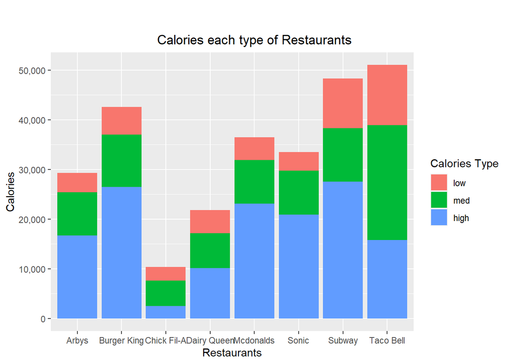

```r
fastfood_calories_type %>%
  ggplot(aes(x=restaurant, y=calories, fill=calories_type))+
  geom_col() +
  scale_y_continuous(labels= scales :: comma) +
  labs(x="Restaurants", y="Calories", fill="Calories Type", title="

                            Calories each type of Restaurants")
```

### 21. The second variable should show the percentage of `trans_fat` in `total_fat`. Add the variable to the dataset and call it `trans_fat_percent`. Do not forget to save the updated dataset.

```r
fastfood_trans <- fastfood %>%
    mutate(trans_fat_percent = (trans_fat/total_fat) * 100)

  kable(fastfood_trans) %>% kable_styling() %>% scroll_box(width="100%", height="500px")
```

| X | restaurant | item | calories | cal_fat | total_fat | sat_fat | trans_fat | cholesterol | sodium | total_carb | fiber | sugar | protein | vit_a | vit_c | calcium | salad | trans_fat_percent |
| --- | --- | --- | --- | --- | --- | --- | --- | --- | --- | --- | --- | --- | --- | --- | --- | --- | --- | --- |
| 1 | Mcdonalds | Artisan Grilled Chicken Sandwich | 380 | 60 | 7 | 2.0 | 0.0 | 95 | 1110 | 44 | 3 | 11 | 37 | 4 | 20 | 20 | Other | 0.0000000 |
| 2 | Mcdonalds | Single Bacon Smokehouse Burger | 840 | 410 | 45 | 17.0 | 1.5 | 130 | 1580 | 62 | 2 | 18 | 46 | 6 | 20 | 20 | Other | 3.3333333 |
| 3 | Mcdonalds | Double Bacon Smokehouse Burger | 1130 | 600 | 67 | 27.0 | 3.0 | 220 | 1920 | 63 | 3 | 18 | 70 | 10 | 20 | 50 | Other | 4.4776119 |
| 4 | Mcdonalds | Grilled Bacon Smokehouse Chicken Sandwich | 750 | 280 | 31 | 10.0 | 0.5 | 155 | 1940 | 62 | 2 | 18 | 55 | 6 | 25 | 20 | Other | 1.6129032 |
| 5 | Mcdonalds | Crispy Bacon Smokehouse Chicken Sandwich | 920 | 410 | 45 | 12.0 | 0.5 | 120 | 1980 | 81 | 4 | 18 | 46 | 6 | 20 | 20 | Other | 1.1111111 |
| 6 | Mcdonalds | Big Mac | 540 | 250 | 28 | 10.0 | 1.0 | 80 | 950 | 46 | 3 | 9 | 25 | 10 | 2 | 15 | Other | 3.5714286 |
| 7 | Mcdonalds | Cheeseburger | 300 | 100 | 12 | 5.0 | 0.5 | 40 | 680 | 33 | 2 | 7 | 15 | 10 | 2 | 10 | Other | 4.1666667 |
| 8 | Mcdonalds | Classic Chicken Sandwich | 510 | 210 | 24 | 4.0 | 0.0 | 65 | 1040 | 49 | 3 | 6 | 25 | 0 | 4 | 2 | Other | 0.0000000 |
| 9 | Mcdonalds | Double Cheeseburger | 430 | 190 | 21 | 11.0 | 1.0 | 85 | 1040 | 35 | 2 | 7 | 25 | 20 | 4 | 15 | Other | 4.7619048 |
| 10 | Mcdonalds | Double Quarter Pounder® with Cheese | 770 | 400 | 45 | 21.0 | 2.5 | 175 | 1290 | 42 | 3 | 10 | 51 | 20 | 6 | 20 | Other | 5.5555556 |
| 11 | Mcdonalds | Filet-O-Fish® | 380 | 170 | 18 | 4.0 | 0.0 | 40 | 640 | 38 | 2 | 5 | 15 | 2 | 0 | 15 | Other | 0.0000000 |
| 12 | Mcdonalds | Garlic White Cheddar Burger | 620 | 300 | 34 | 13.0 | 1.5 | 95 | 790 | 48 | 3 | 11 | 32 | 10 | 10 | 35 | Other | 4.4117647 |
| 13 | Mcdonalds | Grilled Garlic White Cheddar Chicken Sandwich | 530 | 180 | 20 | 7.0 | 0.0 | 125 | 1150 | 48 | 3 | 11 | 42 | 10 | 20 | 35 | Other | 0.0000000 |
| 14 | Mcdonalds | Crispy Garlic White Cheddar Chicken Sandwich | 700 | 300 | 34 | 9.0 | 0.0 | 85 | 1190 | 67 | 5 | 11 | 33 | 10 | 15 | 35 | Other | 0.0000000 |
| 15 | Mcdonalds | Hamburger | 250 | 70 | 8 | 3.0 | 0.0 | 30 | 480 | 31 | 2 | 6 | 13 | 2 | 2 | 4 | Other | 0.0000000 |
| 16 | Mcdonalds | Lobster Roll | 290 | 50 | 5 | 1.5 | 0.0 | 65 | 630 | 35 | 2 | 3 | 24 | 4 | 6 | 15 | Other | 0.0000000 |
| 17 | Mcdonalds | Maple Bacon Dijon 1/4 lb Burger | 640 | 330 | 36 | 14.0 | 1.5 | 110 | 1260 | 40 | 3 | 10 | 37 | 6 | 15 | 15 | Other | 4.1666667 |
| 18 | Mcdonalds | Grilled Maple Bacon Dijon Chicken Sandwich | 580 | 190 | 21 | 8.0 | 0.0 | 135 | 1890 | 50 | 3 | 14 | 48 | 4 | 30 | 30 | Other | 0.0000000 |
| 19 | Mcdonalds | Crispy Maple Bacon Dijon Chicken Sandwich | 740 | 310 | 35 | 9.0 | 0.5 | 95 | 1780 | 69 | 5 | 14 | 39 | 4 | 20 | 290 | Other | 1.4285714 |
| 20 | Mcdonalds | McChicken | 350 | 130 | 15 | 3.5 | 0.0 | 40 | 600 | 40 | 2 | 5 | 15 | 2 | 2 | 4 | Other | 0.0000000 |
| 21 | Mcdonalds | McDouble | 380 | 160 | 18 | 8.0 | 1.0 | 70 | 840 | 34 | 2 | 7 | 23 | 10 | 2 | 10 | Other | 5.5555556 |
| 22 | Mcdonalds | McRib | 480 | 200 | 22 | 7.0 | 0.0 | 80 | 870 | 45 | 2 | 12 | 25 | 2 | 2 | 6 | Other | 0.0000000 |
| 23 | Mcdonalds | Pico Guacamole 1/4 lb Burger | 580 | 300 | 33 | 12.0 | 1.5 | 95 | 920 | 41 | 4 | 7 | 29 | 8 | 15 | 15 | Other | 4.5454545 |
| 24 | Mcdonalds | Grilled Pico Guacamole Chicken Sandwich | 520 | 160 | 18 | 6.0 | 0.0 | 115 | 1540 | 50 | 4 | 12 | 40 | 8 | 25 | 30 | Other | 0.0000000 |
| 25 | Mcdonalds | Crispy Pico Guacamole Chicken Sandwich | 680 | 280 | 32 | 7.0 | 0.0 | 80 | 1430 | 69 | 6 | 12 | 31 | 8 | 15 | 30 | Other | 0.0000000 |
| 26 | Mcdonalds | Premium Buttermilk Crispy Chicken Deluxe Sandwich | 570 | 200 | 23 | 5.0 | 0.0 | 60 | 1050 | 64 | 4 | 11 | 28 | 4 | 10 | 20 | Other | 0.0000000 |
| 27 | Mcdonalds | Premium Crispy Chicken Deluxe Sandwich | 530 | 200 | 22 | 4.0 | 0.0 | 45 | 1000 | 59 | 3 | 13 | 25 | 6 | 10 | 20 | Other | 0.0000000 |
| 28 | Mcdonalds | Quarter Pounder® with Cheese | 530 | 240 | 27 | 13.0 | 1.5 | 100 | 1090 | 41 | 3 | 10 | 31 | 20 | 6 | 15 | Other | 5.5555556 |
| 29 | Mcdonalds | Signature Sriracha Burger | 670 | 320 | 35 | 12.0 | 1.5 | 95 | 1010 | 56 | 4 | 13 | 32 | 20 | 15 | 30 | Other | 4.2857143 |
| 30 | Mcdonalds | Grilled Signature Sriracha Chicken Sandwich | 560 | 180 | 20 | 5.0 | 0.0 | 115 | 1550 | 56 | 4 | 14 | 41 | 20 | 25 | 30 | Other | 0.0000000 |

[output cut: 485 more lines]

### 22. Create a dataviz that shows the distribution of `trans_fat` in food items for each type of restaurant. Think carefully about the choice of data viz. Use facets, coordinates and theme layers to make your data viz visually appealing and meaningful.

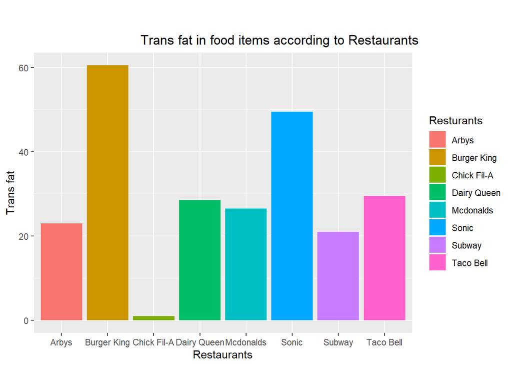

```r
fastfood %>%
  ggplot(aes(x=restaurant, y=trans_fat, fill=restaurant))+
  geom_col() +
  scale_y_continuous(labels= scales :: comma) +
  labs(x="Restaurants", y="Trans fat", fill="Resturants", title="

                            Trans fat in food items according to Restaurants")
```

### 23. Calculate and show the average (mean) `total_fat` for each type of restaurant. No need to save it as a variable.

```r
fastfood %>%
  group_by(restaurant) %>%
  summarise(total_fat_average=mean(total_fat)) %>%
  ungroup() %>%
  kable() %>% kable_styling() %>% scroll_box(width="100%", height="300px")
```

| restaurant | total_fat_average |
| --- | --- |
| Arbys | 26.98182 |
| Burger King | 36.81429 |
| Chick Fil-A | 16.14815 |
| Dairy Queen | 28.85714 |
| Mcdonalds | 31.80702 |
| Sonic | 37.64151 |
| Subway | 18.47917 |
| Taco Bell | 20.89565 |

### 24. And create a dataviz that allow to compare different restaurants on this variable (`total_fat`). You can present it on one dataviz (= no facets). Think carefully about the choice of data viz. Use coordinates and theme layers to make your data viz visually appealing and meaningful.

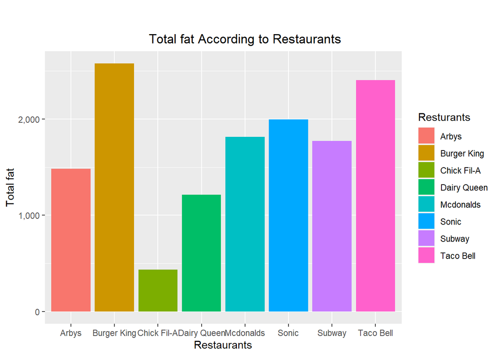

```r
fastfood %>%
  ggplot(aes(x=restaurant, y=total_fat, fill= restaurant))+
  geom_col() +
  scale_y_continuous(labels= scales :: comma) +
  labs(x="Restaurants", y="Total fat", fill="Resturants", title="

                            Total fat According to Restaurants")
```